# Part II - The Effect of Prosper Rating and HomeOwner Status of a Borrower on the Borrower's Interest Rate and APR

## by Nafisa Opemi Jimoh

## Investigation Overview

> The main goal of this presentation is to show the effect of prosper rating and borrowers home status on the borrower interest rate and APR.

**Key Insights:**

- The higher the prosper rating, the higher the interest rate. Borrowers with the lowest prosper ratings had lower interest rate associated with their loans.
- Not being a home owner as a borrower will have an effect on the APR because borrowers without a home is depicted to have a higher APR on their loans.

## Dataset Overview

> The dataset comprises of 113,937 rows and 81 columns. It contains loan listing from 2005 - 2014. Features include creation date, borrowerAPR, term of payment, borrowerRate, prosper rating and others.

## Prosper Rating Distribution

> The prosper rating is the expected level of risk associated with a loan listing. This is assigned to each borrower loan at the time the listing was created. It has 7 grades ranging from lowest to highest: AA, A, B, C, D, E and HR. The rating with the highest number of borrowers on the prosper loan platform is C having 21% while the lowest risk rating takes upto 6.3% of the total number of borrowers on the Prosper Rating platform.

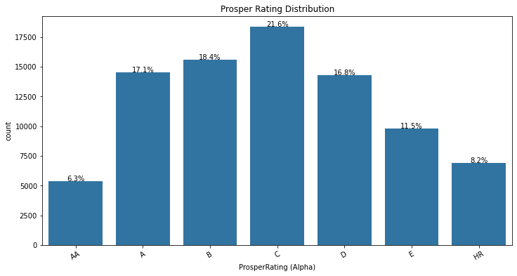

## Borrowers Interest Rate

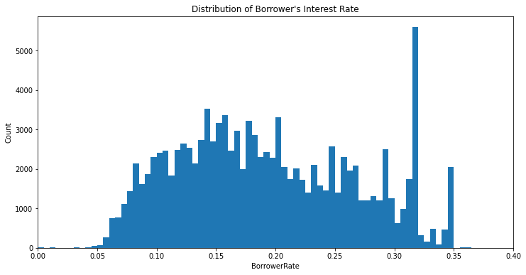

## Effect of Prosper Rating on BorrowerRate

> The higher the risk associated with a loan listing, the higher the interest rate. Borrowers given a rating of AA had interest rates lesser than 0.15.

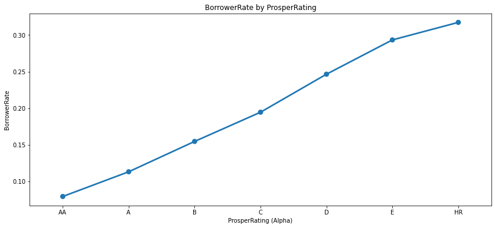

## Effect of the Term of Payement and Prosper Rating on the Interest Rate

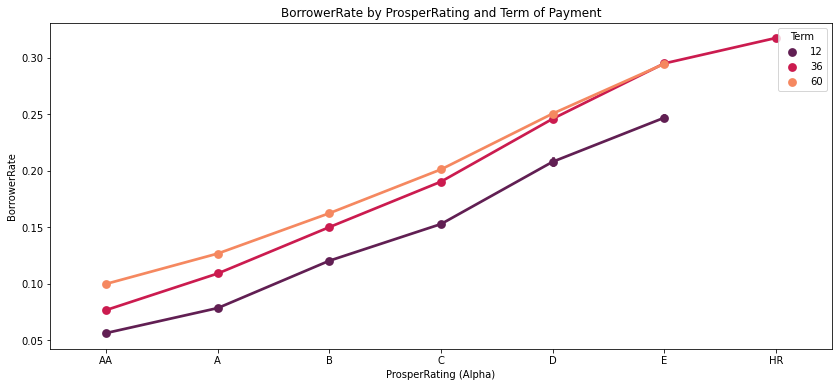

## HomeOwner Status on the Borrower APR

> Over the years, the borrowers APR for those who aren't home ownners are higher than borrowers who are home owners. Perhaps the houses were seen as a form bond incase the borrower does not meet up with payment.

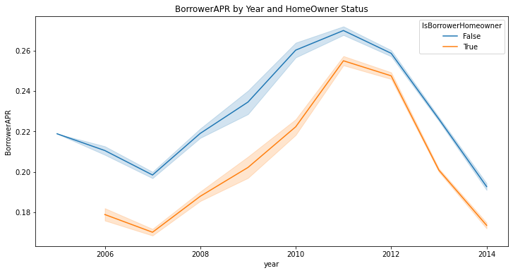